# Attainment and Attendance across Sussex

East Sussex, West Sussex and Brighton and Hove through the national model behind *How to Pull the Right Lever*: one region, three different school systems. **Draft for discussion.**

Author

Affiliation

Adam Dennett

Bartlett Centre for Advanced Spatial Analysis, University College London

Published

October 30, 2026

**WarningDraft for discussion**

This review draws together the East Sussex, West Sussex and Mid Sussex documents, and the Brighton and Hove findings of [How to Pull the Right Lever](https://adamdennett.github.io/school_attainment_tool/pulling_the_right_lever_v2.html). Every figure comes from published Department for Education data and the national models documented there. Nothing uses pupil-level records.

# Summary

Sussex has 76 state-funded secondary schools across three local authorities and thirteen districts. Taken together in 2024-25:

- **Results:** 45.4 in Attainment 8, against 46.9 for England.
- **Disadvantaged pupils:** 33.4 against 37.8.
- **Disadvantage:** 21.5% of pupils are disadvantaged, against 28.3% nationally.

Sussex is less disadvantaged than England, does a little less well overall, and does markedly less well by its disadvantaged pupils. The findings:

- **The disadvantaged shortfall is the region’s shared problem.** Every one of the three authorities is below England for its disadvantaged pupils. The largest single cause is being in the South East (1.3 points). Of England’s nine regions, the South East has the most negative regional effect for disadvantaged pupils. Absence and prior attainment add to it.
- **Beneath that, three different systems.**
  - *Brighton and Hove* has effective schools held back by absence far beyond what its intake predicts.
  - *East Sussex* has schools that do about what is expected, pupils with lower prior attainment, and the absence its intake predicts.
  - *West Sussex* has an advantaged intake, ordinary attendance, and schools below expectation, most of all for disadvantaged pupils.
- **Illness drives Sussex’s excess absence everywhere.** All three authorities record more illness absence than England, Brighton and Hove most of all. Reduced timetables run above the national rate in East and West Sussex.
- **The practice gaps are large and specific.** East Sussex suspends at twice Brighton and Hove’s rate, and West Sussex uses reduced timetables at about twice the national rate.
- **Place matters within the region, but mostly as schools.** Average value added runs from +2.4 points in Worthing to -3.6 in Hastings. But only Crawley has a district effect that survives once each school’s own record is counted.
- **Trusts matter about as much as local authorities,** more for disadvantaged pupils and attendance. United Learning runs schools in both counties and stands out for results. Ark (Hastings) stands out for disadvantaged pupils and attendance. Kemnal (West Sussex) and Aldridge (Brighton and Hove) run significantly more absence than their intakes predict.
- **In none of the three does the mix of pupils between schools explain results.** Attendance, prior attainment, and what happens inside particular schools do.

# 1 About this review

The three authority-level documents each apply the published national models to one authority. This review sets them side by side and adds the view of Sussex as one system. Two things should be borne in mind:

- **Sussex is not an administrative unit** for schools. Its three authorities have their own admissions, school improvement and attendance services. “Sussex” here is a lens, not a governing body.
- **Brighton and Hove** is the subject of the Lever report itself. Its figures here come from the same models and data.

The methods are described in full in the East Sussex document.

# 2 Sussex’s schools

[interactive chart not shown]

Sussex’s 76 state-funded secondary schools, coloured by overall absence in 2024/25, within its thirteen districts. Choose another measure from the menu above the map; circle size is the school’s roll. Hover for figures and who runs each school.

Table 1: Who ran Sussex’s secondary schools in 2024/25.

| Local authority | Maintained | Multi-academy trust | Single-academy trust or not recorded | Sponsored | Trusts | Schools |
| --- | --- | --- | --- | --- | --- | --- |
| Brighton and Hove | 7 | 3 | 0 | 2 | 2 | 10 |
| East Sussex | 8 | 15 | 3 | 6 | 11 | 26 |
| West Sussex | 18 | 21 | 1 | 9 | 12 | 40 |

The three authorities run their schools very differently:

- **Brighton and Hove** maintains seven of its ten.
- **West Sussex** maintains nearly half.
- **East Sussex** has most of its schools in 11 different multi-academy trusts.

Two trusts, United Learning and the University of Brighton Academies Trust, ran schools in both counties in 2024/25.

# 3 Three systems in one region

Sussex and its three authorities against England, 2024/25. Means of school-level figures; ranks among all local authorities (1 = highest).

| Measure | Sussex | East Sussex | West Sussex | Brighton and Hove | England |
| --- | --- | --- | --- | --- | --- |
| Attainment 8, all pupils | 45.4 | 43.8 (120th) | 46.4 (71st) | 45.5 (85th) | 46.8 |
| Attainment 8, disadvantaged | 33.4 | 33.0 (135th) | 33.5 (127th) | 33.9 (122nd) | 37.7 |
| Attainment 8, non-disadvantaged | 48.5 | 47.5 (118th) | 48.9 (83rd) | 49.6 (68th) | 49.9 |
| Disadvantage gap (points) | 15.1 | 14.5 (29th) | 15.4 (16th) | 15.7 (13th) | 12.2 |
| Disadvantaged (FSM6) % | 21.5 | 25.5 (89th) | 17.1 (143rd) | 28.8 (74th) | 28.4 |
| Overall absence % | 9.4 | 9.7 (27th) | 8.7 (71st) | 11.3 (1st) | 8.6 |
| Persistent absence % | 25.6 | 26.4 (31st) | 23.9 (79th) | 30.6 (4th) | 23.9 |
| Mean KS2 (centred) | 4.16 | 3.79 (112th) | 4.26 (79th) | 4.71 (50th) | 4.47 |
| EAL % | 9.6 | 6.3 (130th) | 11.0 (97th) | 13.0 (83rd) | 18.4 |

Table 2: What the national model says about each authority: its own effect once intake and circumstances are accounted for (rank, 1 = best), and whether its standing depends on controlling for absence.

| Local authority | All pupils | Disadvantaged | Disadvantaged rank: with / without absence control | Absence above intake-predicted |
| --- | --- | --- | --- | --- |
| East Sussex | +1.1% (49th) | +0.9% (60th) | 57th / 61st | +0.32 (59th) |
| West Sussex | -1.5% (115th) | -3.8% (131st)* | 132nd / 133rd | +0.03 (92nd) |
| Brighton and Hove | +4.5% (5th)* | +4.2% (14th)* | 15th / 69th | +1.98 (3rd) |

`*` marks an effect distinguishable from zero.

Read across the two tables, the three authorities are three distinct cases:

- **Brighton and Hove** is the strongest on the model: its schools are 5th in England once intake is accounted for. It is also the most dependent on absence: it falls from 15th to 69th for disadvantaged pupils without the absence control, because its absence is the 3rd furthest above its intake in England.
- **East Sussex** is in the middle on every measure. Its schools do what is expected, and its absence is what its intake predicts.
- **West Sussex** is the reverse of Brighton and Hove: absence is ordinary, and its schools sit significantly below expectation for disadvantaged pupils (131st of 151).

# 4 What explains attainment across Sussex

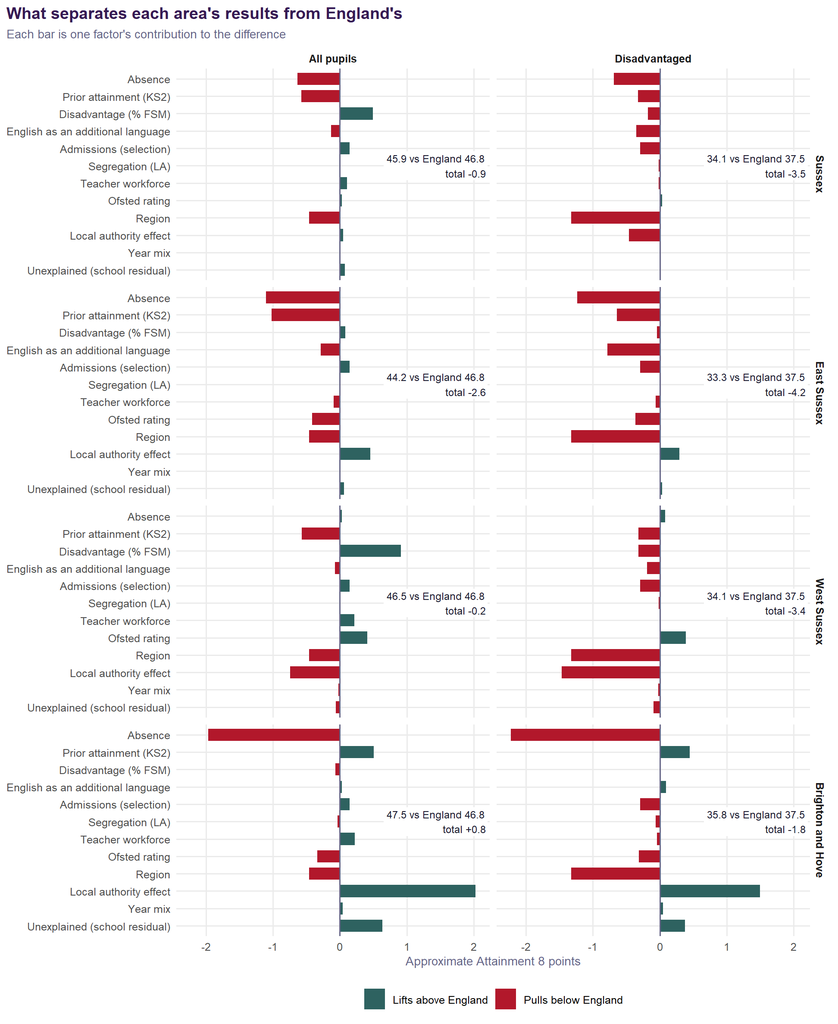

Figure 1: Why average Attainment 8 differs from England’s, by factor, all school-years 2021/22 to 2024/25, for Sussex as a whole and its three authorities. Approximate Attainment 8 points; the pieces sum to the total printed in each panel.

The decomposition for Sussex as a whole, in Attainment 8 points.

| Factor | All pupils | Disadvantaged | Non-disadvantaged |
| --- | --- | --- | --- |
| Absence | -0.63 | -0.69 | -0.50 |
| Prior attainment (KS2) | -0.57 | -0.33 | -0.46 |
| Place (region and local authority) | -0.41 | -1.78 | -0.38 |
| English as an additional language | -0.13 | -0.36 | -0.19 |
| Ofsted rating | +0.03 | +0.03 | +0.03 |
| Unexplained (school residual) | +0.08 | +0.01 | +0.05 |
| Teacher workforce | +0.11 | -0.02 | +0.10 |
| Other model terms | +0.13 | -0.32 | +0.11 |
| Disadvantage (% FSM) | +0.49 | -0.18 | +0.27 |

**Sussex as a whole** is 0.9 points below England for all pupils. Its low disadvantage lifts it (+0.49), and three things pull it down:

- absence (-0.63);
- prior attainment (-0.57);
- being in the South East (-0.46).

The three authorities’ own effects roughly cancel. Brighton and Hove’s positive effect offsets West Sussex’s negative one.

**For disadvantaged pupils** Sussex is 3.5 points below England. The largest single piece is the region (-1.32), followed by absence (-0.69) and the authorities’ own effects (-0.46, mostly West Sussex’s).

The regional effect is not something any one authority can change, but it is real and it is shared. Of England’s nine regions, the South East has the most negative effect for disadvantaged pupils: they do less well there than equally disadvantaged pupils elsewhere with the same prior attainment and attendance. That is a regional question as much as a local one.

# 5 Place: authorities and districts

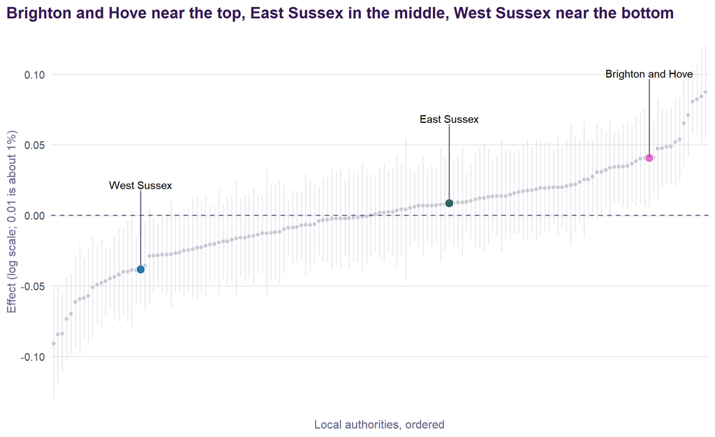

Figure 2: Local authority effects from the published national models, disadvantaged pupils, every authority in England with a 95% interval.

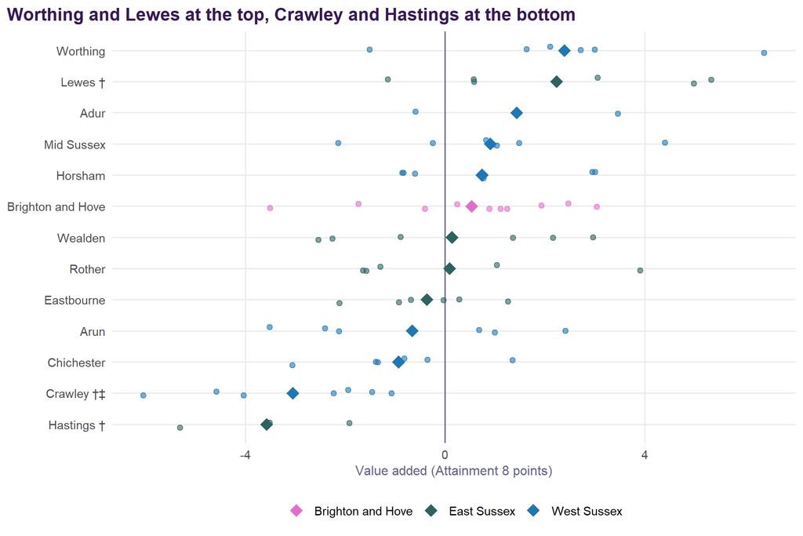

Figure 3: Sussex’s thirteen districts: each school’s value added (mean 2021/22 to 2024/25, small dots) and the district mean (large dots), coloured by authority. Districts marked † have a significant district effect on the published model; only Crawley’s (‡) survives once each school’s own record is counted, and then only for non-disadvantaged pupils.

Table 3: Sussex’s districts, 2024/25 profile and mean value added over 2021/22 to 2024/25.

| District | Authority | Schools | FSM % | Absence % | KS2 | Att 8 | Att 8 disadv. | Value added | Schools below expectation |
| --- | --- | --- | --- | --- | --- | --- | --- | --- | --- |
| Worthing | West Sussex | 6 | 17.6 | 8.4 | 4.2 | 49.0 | 35.8 | +2.4 | 0 of 6 |
| Lewes | East Sussex | 6 | 21.5 | 10.2 | 3.2 | 45.4 | 32.2 | +2.2 | 0 of 6 |
| Adur | West Sussex | 2 | 20.0 | 8.3 | 4.6 | 48.4 | 40.0 | +1.4 | 0 of 2 |
| Mid Sussex | West Sussex | 7 | 12.2 | 8.3 | 5.0 | 50.3 | 35.5 | +0.9 | 0 of 7 |
| Horsham | West Sussex | 6 | 11.9 | 8.0 | 5.4 | 49.6 | 34.6 | +0.7 | 0 of 6 |
| Brighton and Hove | Brighton and Hove | 10 | 28.8 | 11.3 | 4.7 | 45.5 | 33.9 | +0.5 | 0 of 10 |
| Wealden | East Sussex | 6 | 20.0 | 9.4 | 4.4 | 45.1 | 34.0 | +0.1 | 0 of 6 |
| Rother | East Sussex | 5 | 25.6 | 9.4 | 5.2 | 45.4 | 34.5 | +0.1 | 0 of 5 |
| Eastbourne | East Sussex | 6 | 30.0 | 9.4 | 2.7 | 42.7 | 33.2 | -0.4 | 1 of 6 |
| Arun | West Sussex | 6 | 18.6 | 9.1 | 3.3 | 43.1 | 31.2 | -0.7 | 1 of 6 |
| Chichester | West Sussex | 6 | 17.8 | 8.9 | 3.8 | 43.6 | 31.0 | -0.9 | 1 of 6 |
| Crawley | West Sussex | 7 | 23.4 | 9.3 | 3.8 | 42.1 | 30.7 | -3.1 | 1 of 7 |
| Hastings | East Sussex | 3 | 35.1 | 10.1 | 3.7 | 37.8 | 29.5 | -3.6 | 1 of 3 |

The lesson is consistent across the region. A district is a useful way to see where difficulties gather, but in all but one case the difficulty belongs to particular schools, not to the place.

# 6 Trusts across Sussex

In 2024/25, 23 multi-academy trusts ran Sussex secondary schools, most of them one or two schools each. The trust analysis in the East Sussex document estimates every trust’s effect across all its secondary schools in England. It allows for each school’s own record and for whether it was sponsored. Nationally, a trust moves results by about 2.2%, about as much as a local authority, and absence by about 6.7%.

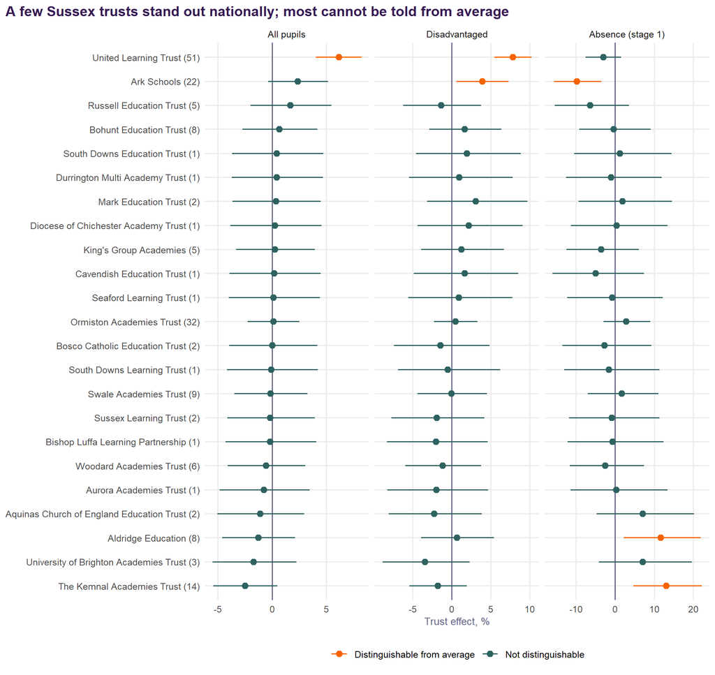

Figure 4: The national effect of each trust that ran a Sussex secondary school in 2024/25, with 95% intervals; the number of its schools in the national data is in brackets.

Four of the trusts running Sussex schools stand out nationally:

- **Above average:**
  - for all pupils: United Learning Trust;
  - for disadvantaged pupils: Ark Schools, United Learning Trust.
- **Absence below what their intakes predict:** Ark Schools.
- **Absence above what their intakes predict:** Aldridge Education, The Kemnal Academies Trust.

Most of the rest are small trusts that cannot be separated from their one or two schools.

Nothing here suggests that academies as a group do better or worse than maintained schools in Sussex. Nationally, the differences by route are a percent or two once intake is allowed for. The region’s strongest schools on value added are a mix of maintained schools (St Oscar Romero, St Richard’s, Downlands) and academies (King’s Academy Ringmer, Durrington, Steyning).

# 7 Absence across Sussex

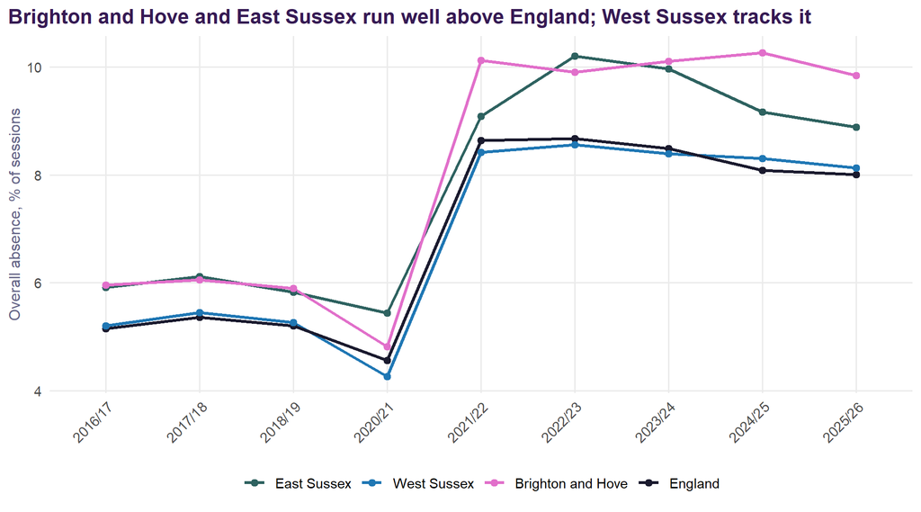

Figure 5: Overall absence in state-funded secondary schools, autumn and spring terms, 2016/17 to 2025/26. Sessions-weighted; 2019/20 not collected.

In autumn and spring 2025/26:

- **Brighton and Hove**: 9.8%, 6th highest in England.
- **East Sussex**: 8.9%, 31st, falling fast.
- **West Sussex**: 8.1%, 70th, close to England’s 8.0%.

Only Brighton and Hove’s is much above what its intake predicts.

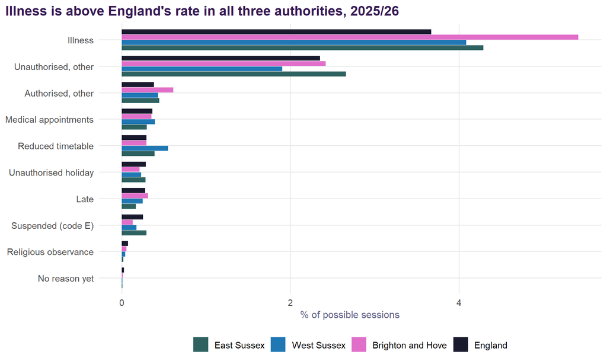

Figure 6: Absence by register reason, autumn and spring terms, percentage of possible sessions. The ten largest reasons nationally.

Table 4: Three measures of practice: illness absence, reduced timetables and sessions lost to suspension (percentage of possible sessions, latest absence year), and suspensions per 100 pupils (latest exclusions year).

| Area | Illness | Reduced timetable | Suspended (code E) | Suspensions per 100 |
| --- | --- | --- | --- | --- |
| East Sussex | 4.29 | 0.39 | 0.29 | 28.0 |
| West Sussex | 4.09 | 0.55 | 0.18 | 16.2 |
| Brighton and Hove | 5.42 | 0.29 | 0.13 | 13.0 |
| Sussex | 4.34 | 0.46 | 0.21 | 19.4 |
| England | 3.67 | 0.29 | 0.25 | 21.2 |

The table shows three things:

- **Illness is the shared problem.** It is above England’s rate everywhere, and in Brighton and Hove by a margin (5.42% against 3.67%). The published data cannot say what lies behind it. All three authorities’ own records could, and comparing them is the obvious first step.
- **Reduced timetables are West Sussex’s outlier**, at 1.9 times England’s rate.
- **Suspension is East Sussex’s outlier**, at 28.0 per 100 pupils against 13.0 in Brighton and Hove. Neighbouring authorities with similar pupils make very different decisions about exclusion, which suggests these are choices that can be changed.

# 8 School by school

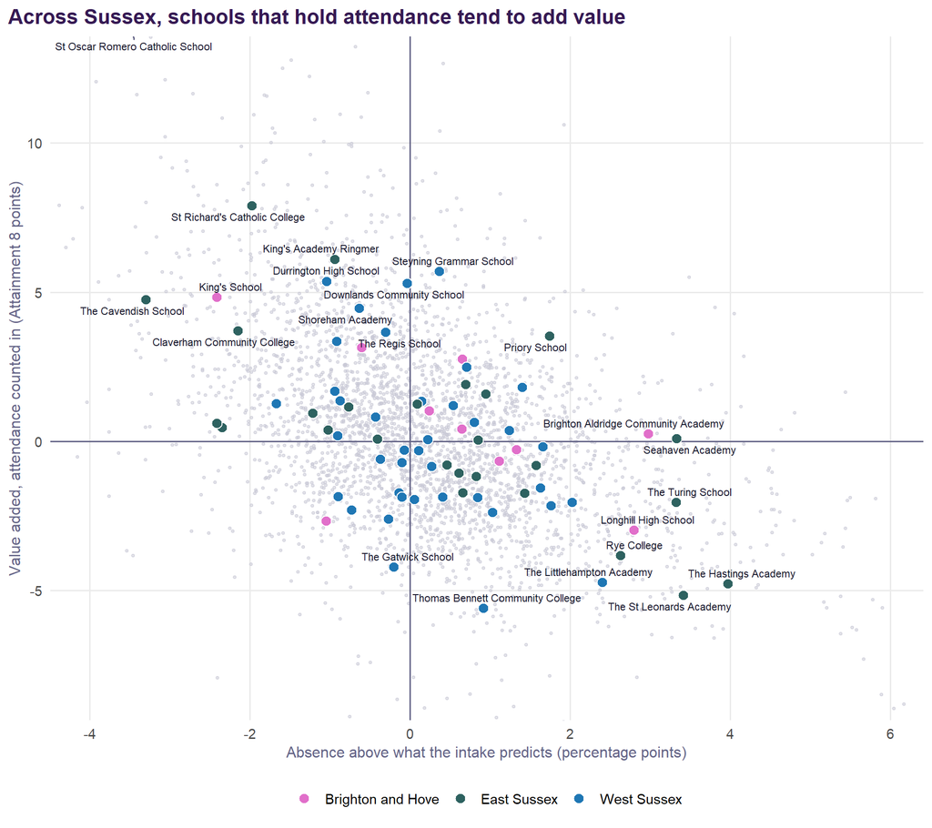

Figure 7: All 76 Sussex schools on the joint-signal plane, mean over 2021/22 to 2024/25: absence above or below what the intake predicts, against value added with attendance counted in. Grey: every school in England.

Across Sussex’s schools the two signals move together (correlation -0.58). The schools furthest out are named.

- **Strongest:** St Oscar Romero (Worthing), St Richard’s (Bexhill) and King’s Academy Ringmer.
- **Weakest:** Thomas Bennett (Crawley), the two Hastings academies, and The Littlehampton Academy.

Both Hastings academies have since moved to a new trust.

Table 5: The ten Sussex schools furthest above and below the national model’s expectation, mean value added 2021/22 to 2024/25 (Attainment 8 points), with absence above or below intake.

| Group | School | Authority | Run by (2024/25) | Value added | Absence vs intake |
| --- | --- | --- | --- | --- | --- |
| Above | St Oscar Romero Catholic School | West Sussex | Maintained by the council | +14.1 | -3.5 |
| Above | St Richard's Catholic College | East Sussex | Maintained by the council | +7.9 | -2.0 |
| Above | King's Academy Ringmer | East Sussex | King's Group Academies | +6.1 | -0.9 |
| Above | Steyning Grammar School | West Sussex | Bohunt Education Trust | +5.7 | +0.4 |
| Above | Durrington High School | West Sussex | Durrington Multi Academy Trust | +5.4 | -1.0 |
| Above | Downlands Community School | West Sussex | Maintained by the council | +5.3 | -0.0 |
| Above | King's School | Brighton and Hove | Russell Education Trust | +4.8 | -2.4 |
| Above | The Cavendish School | East Sussex | Cavendish Education Trust | +4.8 | -3.3 |
| Above | Shoreham Academy | West Sussex | United Learning Trust | +4.5 | -0.6 |
| Above | Claverham Community College | East Sussex | Maintained by the council | +3.7 | -2.2 |
| Below | Felpham Community College | West Sussex | Maintained by the council | -2.4 | +1.0 |
| Below | St Paul's Catholic College | West Sussex | Bosco Catholic Education Trust | -2.6 | -0.3 |
| Below | Patcham High School | Brighton and Hove | Maintained by the council | -2.7 | -1.0 |
| Below | Longhill High School | Brighton and Hove | Maintained by the council | -3.0 | +2.8 |
| Below | Rye College | East Sussex | Aquinas Church of England Education Trust | -3.8 | +2.6 |
| Below | The Gatwick School | West Sussex | Aurora Academies Trust | -4.2 | -0.2 |
| Below | The Littlehampton Academy | West Sussex | Woodard Academies Trust | -4.7 | +2.4 |
| Below | The Hastings Academy | East Sussex | University of Brighton Academies Trust | -4.8 | +4.0 |
| Below | The St Leonards Academy | East Sussex | University of Brighton Academies Trust | -5.1 | +3.4 |
| Below | Thomas Bennett Community College | West Sussex | The Kemnal Academies Trust | -5.6 | +0.9 |

# 9 Implications for Sussex

1. **Disadvantaged pupils are the regional priority.** All three authorities are below England for them. A part of the shortfall is regional and shared, and so is the case for working on it together.
2. **Each authority has a different first lever.**
   - *Brighton and Hove:* attendance, and finding out why its absence is so far above its intake.
   - *East Sussex:* attendance, prior attainment, and its high suspension rate.
   - *West Sussex:* what happens inside its schools for disadvantaged pupils, starting with Crawley.

   A single Sussex-wide prescription would fit none of them.
3. **Illness absence is common to all three,** and their combined records could show what lies behind it in a way no one authority’s could.
4. **Practice varies more than intake does.** Suspension in East Sussex and reduced timetables in West Sussex are choices made within the system, and neighbouring authorities make them differently.
5. **Schools, not structures, carry most of the variation.** Districts and trusts matter at the margin. The strongest effects in every analysis here belong to individual schools. Learning from the region’s best schools is the most direct lever available, and those schools include maintained schools and academies alike.

# Notes on method

Methods and sources are those of the East Sussex document. “Sussex” figures are means over all 76 schools (for school-level measures) or sums over their sessions and pupils (for absence and suspensions). This review is built by `R/17_area_analysis.R`, `R/18_district_effects.R`, `R/19_trust_effects.R`, `R/19b_sussex_boundaries.R` and `sussex_review.qmd`.